# Room Costs in Norwegian Counties

Lucas Stark

18 9 2019

## 0.1 Introduction

The data for this project was taken from the webpage of the [statistisk sentralbyrå](http://data.ssb.no/api/v0/dataset/) of Norway. Two datasets about prices and capacities of rooms for overnight stays were downloaded into R (Version 3.6.0). After this, the dataframes were merged and cleaned. Eventually, a difference score between the individual mean values of the Norwegian counties’ price per room and the mean of the overall mean of Norway was computed.

## 0.2 Analysis

### 0.2.1 Least and most expensive counties and years

Two aspects of the dataframe were analyzed to get an overview over the relative price situation inbetween Norwegian counties.

First, a mean value was computed for each county over every year of data observation. That made apparent that Svalbard was the most expensive county with 346.96 NOK per room above the national average. Oppland was the least expensive county with -76.13 NOK below the national average.

Second, a mean value was computed for each year over every county. That made apparent that 2019 was the most expensive year with 10.14 NOK per room above the average of all years. 2008 was the least expensive year with -36.81 NOK below the average.

### 0.2.2 Troms’ Prices per Room over Time from 1999 till Today

As a next step, the monthly averages of prices per room for the Troms county were checked in comparison to the national average.

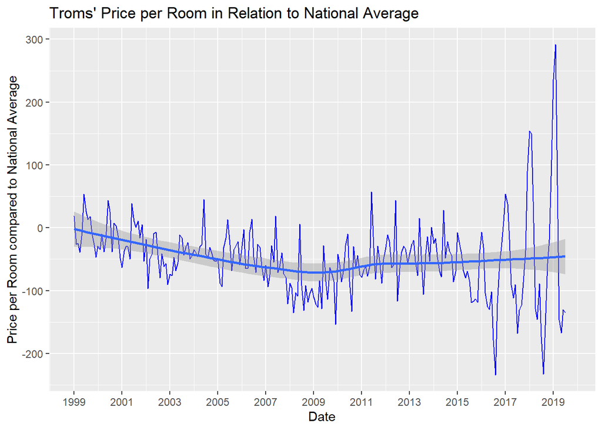

The graph shows that the room prices in the county of Troms were mostly below average after 1999. However, since 2016 the prices started to variate more extreme.

### 0.2.3 Relationship between Room Capacity and Price since January 2010

Per county, is there any relationship between room capacity and price since January 2010? For this, the correlations for each county were computed. These can be seen in the following table.

| County | Correlation | P value |
| --- | --- | --- |
| Østfold | 0.42 | 0.00 |
| Akershus | 0.19 | 0.04 |
| Oslo | 0.47 | 0.00 |
| Hedmark | 0.38 | 0.00 |
| Oppland | 0.35 | 0.00 |
| Buskerud | -0.20 | 0.03 |
| Vestfold | -0.02 | 0.81 |
| Telemark | 0.16 | 0.09 |
| Aust-Agder | 0.49 | 0.00 |
| Vest-Agder | 0.76 | 0.00 |
| Rogaland | 0.35 | 0.00 |
| Hordaland | 0.66 | 0.00 |
| Sogn og Fjordane | 0.17 | 0.07 |
| Møre og Romsdal | 0.63 | 0.00 |
| Sør-Trøndelag | 0.39 | 0.00 |
| Nord-Trøndelag | 0.22 | 0.02 |
| Nordland | 0.32 | 0.00 |
| Troms - Romsa | 0.50 | 0.00 |
| Finnmark - Finnmárku | 0.27 | 0.00 |
| Svalbard | 0.68 | 0.00 |
| Trøndelag | 0.44 | 0.06 |

It is observable that more than half of the correlations are significant with a significance level of $\alpha < .05$. The average of these significant correlations is 0.4. This speaks for an overall positive relationship between room capacity and price in these counties.